# BKMR model for birth weight

Sheena Martenies

2/24/2020

This document summarizes the prelimiary results of the Bayesian Kernel Machine Regression (BKMR) model for birth weight. The analysis builds on the original CEI paper, where we developed an index to characterize combined exposures to environmental and social determinants of health and their associations with birth weight and adiposity at birth in the Healthy Start cohort.

Here I am presenting the results of the preliminary BKMR model for birth weight.

For this analysis, we take a subset of those predictors (as selected using the NPS algorithm) and fit a BKMR model to assess independent and joint effects of the exposures. When implementing the NPB model, We used a (conservative) PIP of 0.25 determine which exposures would carry over to the BKMR model. The NPB model selected 9 of the original 19 exposures: mean PM<sub>2.5</sub>, percent impervious surfaces, distance to mines or oil and gas wells, cardiovascular hospitalization rates, respiratory hospitalization rates, property crime rates, the percentage of the population with less than a high school diploma, the percentage of the civilian workforce population that was unemployed, and the percentage of households living in poverty.

Prior to fitting the BKMR model, the outcome, exposure, and individual-level covariates (based on the literature and the previous CEI paper) were scaled.

Of the original 1410 mother-child pairs in the cohort, we have complete data for 780 (55%) pairs.

### Results summary

The results so far suggest:

- the overall mixture has an inverse relationship with birth weight, where higher exposures are associated with lower birth weight
- the three exposures with the highest PIPs are respiratory hospitalization rates (PIP = 0.41), percentage of households in poverty (PIP = 0.38), and percent impervious surface (POP = 0.35)
- Some of the exposures displayed (potenitally) non-linear exposure-response curves (including PM2.5 and property crime rates) though these were not the most important exposures
- The effects of individual exposures were influenced by the other exposures (evidence of effect modification?)
- The stongest relationship with birth weight was observed for respiratory hospitalization rates
- There was little evidence of interations?

### Data exploration

Is there sufficient variability in the exposures and covariates? What does the outcome (birth weight) look like?

```r
var(Z.scaled)
```

```
##                         mean_pm pct_impervious dist_m_mine_well
## mean_pm              1.00000000     0.04491412      -0.26353658
## pct_impervious       0.04491412     1.00000000       0.03848024
## dist_m_mine_well    -0.26353658     0.03848024       1.00000000
## cvd_rate_adj         0.13261601     0.39037390      -0.39546556
## res_rate_adj         0.09467258     0.40975731      -0.21234806
## property_crime_rate  0.08040252     0.21252691      -0.06345950
## pct_less_hs          0.14432522     0.34838683      -0.36575582
## pct_unemp            0.01779691     0.38730765      -0.24954857
## pct_hh_pov           0.08782362     0.56585263      -0.19920768
##                     cvd_rate_adj res_rate_adj property_crime_rate
## mean_pm                0.1326160   0.09467258          0.08040252
## pct_impervious         0.3903739   0.40975731          0.21252691
## dist_m_mine_well      -0.3954656  -0.21234806         -0.06345950
## cvd_rate_adj           1.0000000   0.86634271          0.20654495
## res_rate_adj           0.8663427   1.00000000          0.25558834
## property_crime_rate    0.2065449   0.25558834          1.00000000
## pct_less_hs            0.5738318   0.47241713          0.00689379
## pct_unemp              0.4650842   0.45256051          0.01782784
## pct_hh_pov             0.5323708   0.55887015          0.16855235
##                     pct_less_hs   pct_unemp  pct_hh_pov
## mean_pm              0.14432522  0.01779691  0.08782362
## pct_impervious       0.34838683  0.38730765  0.56585263
## dist_m_mine_well    -0.36575582 -0.24954857 -0.19920768
## cvd_rate_adj         0.57383181  0.46508423  0.53237076
## res_rate_adj         0.47241713  0.45256051  0.55887015
## property_crime_rate  0.00689379  0.01782784  0.16855235
## pct_less_hs          1.00000000  0.63292450  0.72653072
## pct_unemp            0.63292450  1.00000000  0.68812727
## pct_hh_pov           0.72653072  0.68812727  1.00000000
```

```r
var(X.scaled)
```

```
##                     latina_re      black_re      other_re     ed_no_hs
## latina_re       0.19399460189 -0.0435222672 -0.0175438596  0.037819690
## black_re       -0.04352226721  0.1382097363 -0.0110397946  0.014318159
## other_re       -0.01754385965 -0.0110397946  0.0623020967 -0.002567394
## ed_no_hs        0.03781968994  0.0143181594 -0.0025673941  0.130344623
## ed_hs           0.03262729996  0.0158536585  0.0031664527 -0.028241335
## ed_aa           0.01250781739  0.0178335144  0.0041934104 -0.034758566
## ed_4yr         -0.03620683980 -0.0172607880 -0.0031664527 -0.033968599
## low_bmi        -0.00167868075  0.0026068925 -0.0007702182 -0.003456107
## ovwt_bmi        0.02488397354  0.0003357362 -0.0059050064  0.004641059
## obese_bmi       0.02283499556  0.0073121359  0.0023106547  0.005727264
## maternal_age   -0.11130236864 -0.0914960717 -0.0135406562 -0.147331145
## any_smoker     -0.00753760574  0.0150883776 -0.0006846384  0.017379283
## smokeSH        -0.00349725157  0.0321961094  0.0065896448  0.032487410
## mean_cpss      -0.04032749691 -0.0362044396  0.0225734779 -0.057435615
## mean_epsd       0.03908431534  0.0160927464  0.0210839610  0.071535296
## male            0.00152233304 -0.0055544584  0.0021394951 -0.015108127
## gest_age_w     -0.00772944439 -0.0459673981 -0.0051550835 -0.012119005
## days_to_peapod -0.00006310256  0.0353079864  0.0037188443  0.006899213
##                        ed_hs        ed_aa        ed_4yr       low_bmi
## latina_re       0.0326273000  0.012507817 -0.0362068398 -0.0016786808
## black_re        0.0158536585  0.017833514 -0.0172607880  0.0026068925
## other_re        0.0031664527  0.004193410 -0.0031664527 -0.0007702182
## ed_no_hs       -0.0282413350 -0.034758566 -0.0339685988 -0.0034561074
## ed_hs           0.1499144202 -0.041420625 -0.0404792469 -0.0005134788
## ed_aa          -0.0414206247  0.174951450 -0.0498206116  0.0046015602
## ed_4yr         -0.0404792469 -0.049820612  0.1721075672 -0.0003752345
## low_bmi        -0.0005134788  0.004601560 -0.0003752345  0.0298607682
## ovwt_bmi       -0.0069319641  0.017932260  0.0013034462 -0.0080576676
## obese_bmi       0.0268934531  0.012165498 -0.0137849314 -0.0060432507
## maternal_age   -0.1061266380 -0.034152305  0.1077776102 -0.0091971230
## any_smoker      0.0045357296  0.008544814 -0.0153977815  0.0011652019
## smokeSH         0.0251818571  0.021118462 -0.0353773740  0.0026463908
## mean_cpss      -0.0356451617  0.029189204  0.0275174804  0.0079977462
## mean_epsd       0.0221439428  0.016391602 -0.0481925954  0.0107834260
## male            0.0007488233  0.001119121  0.0062868240 -0.0001974919
## gest_age_w     -0.0148312028 -0.025824190  0.0330362179 -0.0033335217
## days_to_peapod  0.0014765999  0.025249438 -0.0107106080 -0.0073703791
##                     ovwt_bmi    obese_bmi maternal_age    any_smoker
## latina_re       0.0248839735  0.022834996 -0.111302369 -0.0075376057
```

[output cut: 40 more lines]

```
## ed_no_hs       -0.012119005  0.00689921335
## ed_hs          -0.014831203  0.00147659993
## ed_aa          -0.025824190  0.02524943813
## ed_4yr          0.033036218 -0.01071060804
## low_bmi        -0.003333522 -0.00737037914
## ovwt_bmi       -0.015929653 -0.01397511387
## obese_bmi      -0.018839063  0.00387449725
## maternal_age    0.073088144 -0.00159199026
## any_smoker     -0.029706937 -0.00228851955
## smokeSH        -0.050997369  0.01073164223
## mean_cpss      -0.007275391 -0.00599542077
## mean_epsd      -0.086750438  0.01124930187
## male           -0.039081937  0.03073094727
## gest_age_w      1.000000000 -0.13525838557
## days_to_peapod -0.135258386  1.00000000000
```

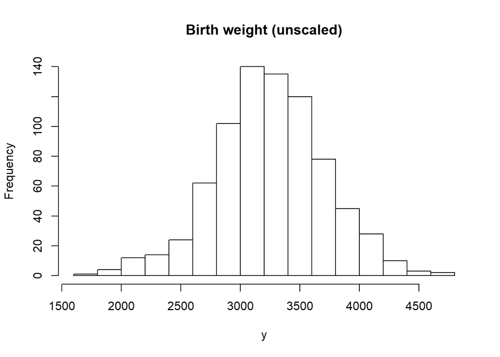

```r
hist(y, main = "Birth weight (unscaled)")
```

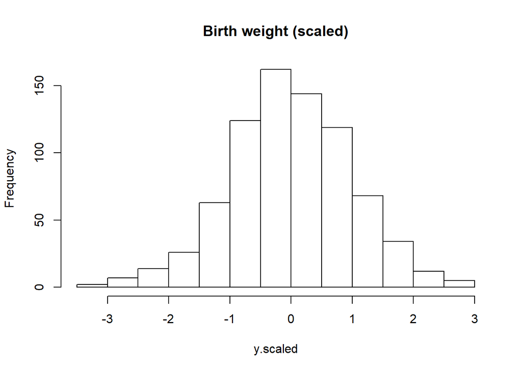

```r
hist(y.scaled, main = "Birth weight (scaled)")
```

### Model fitting

Fitting the BKMR model and investigating model convergence

```
## Fitted object of class 'bkmrfit'
## Iterations: 10000
## Outcome family: gaussian
## Model fit on: 2020-02-19 15:24:30
```

```
##  [1] "h.hat"           "beta"            "lambda"
##  [4] "sigsq.eps"       "r"               "acc.r"
##  [7] "acc.lambda"      "delta"           "acc.rdelta"
## [10] "move.type"       "est.h"           "time1"
## [13] "time2"           "iter"            "family"
## [16] "starting.values" "control.params"  "X"
## [19] "Z"               "y"               "ztest"
## [22] "data.comps"      "varsel"
```

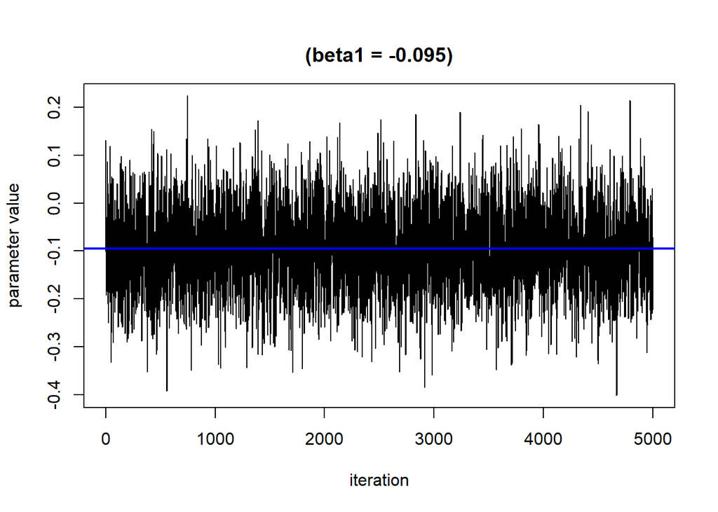

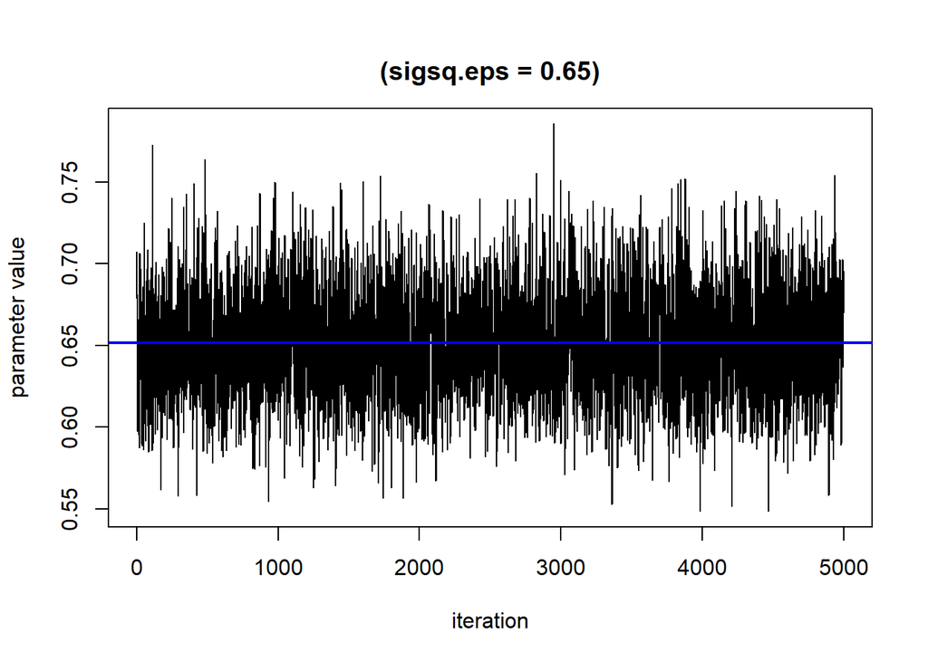

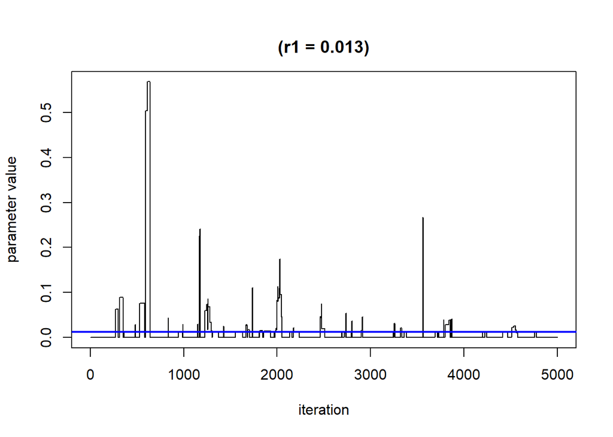

What do the posterior inclusion probabilities (PIPs) look like?

```
##              variable    PIP
## 1        res_rate_adj 0.4064
## 2          pct_hh_pov 0.3774
## 3      pct_impervious 0.3514
## 4           pct_unemp 0.3180
## 5    dist_m_mine_well 0.2446
## 6             mean_pm 0.2366
## 7 property_crime_rate 0.2236
## 8        cvd_rate_adj 0.1878
## 9         pct_less_hs 0.1786
```

How does h(z) compare when using the three different approaches?

```r
h_est_compare
```

```
##   method  post_mean    post_sd
## 1      1 -0.2246116 0.04235168
## 2      2 -0.2435225 0.08547375
## 3      3 -0.2423875 0.08445870
```

### Summarizing the BKMR model

Summarize the BKMR model output: Exposure-response curves for each exposure while holding the others at their 25th, 50th, or 75th percentiles

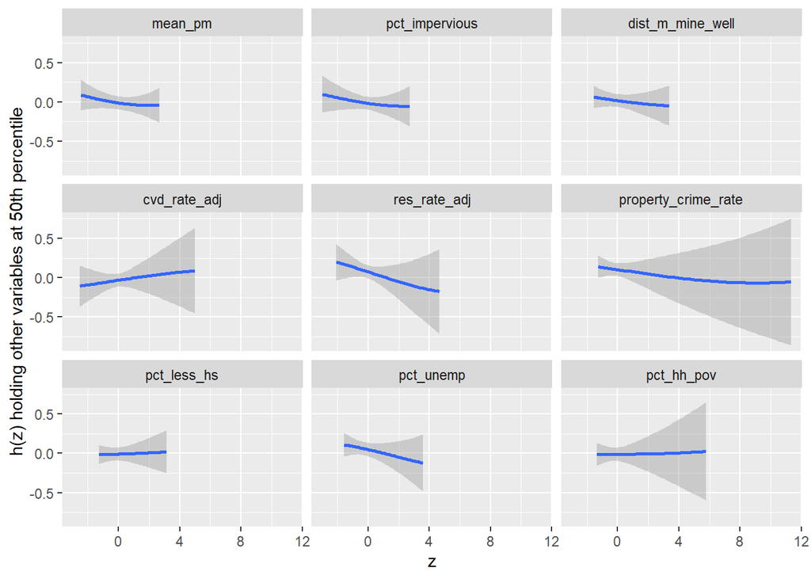

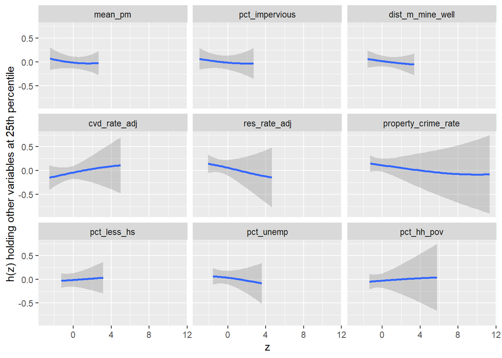

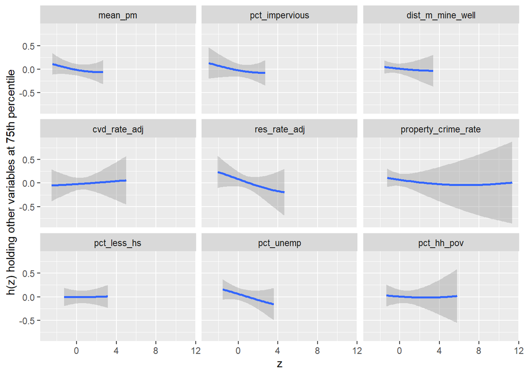

Summarize the BKMR model output: Bivariate relationships between two predictors while holding the others at their 25th, 50th, or 75th percentiles

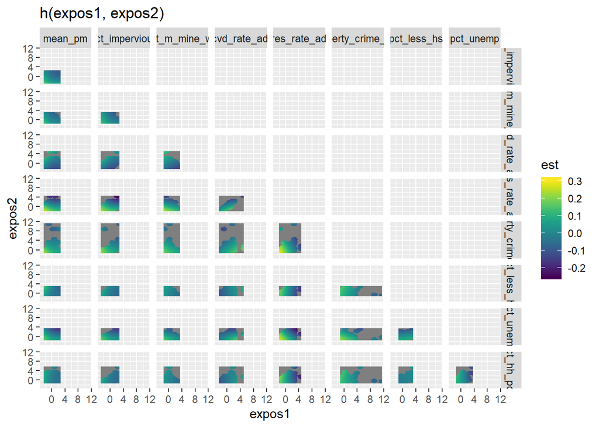

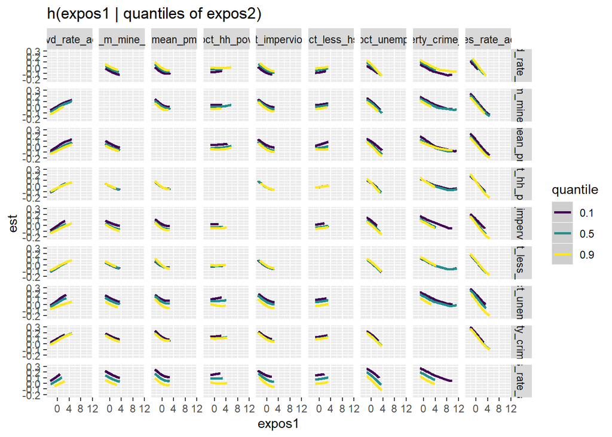

Summarize the BKMR model output: plotting the overall effect size for each percentile relative to the 50th percentile

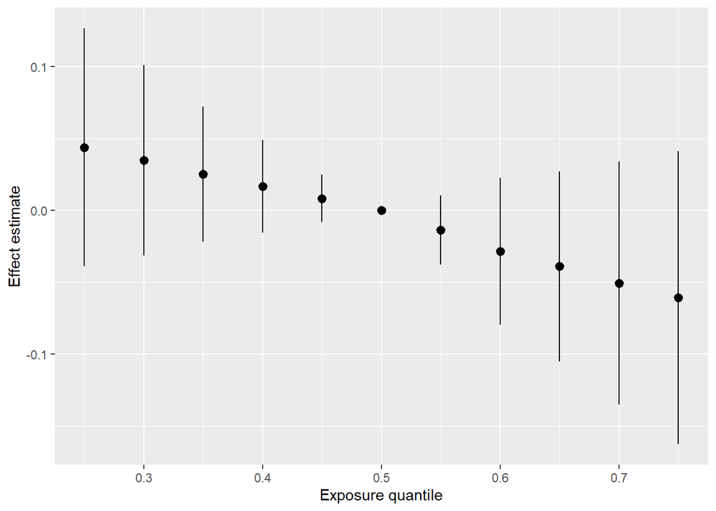

Summarize the BKMR model output: Estimate the risks for the individual variables the exposure is at the 75th percentile relative to the 25th percentile (essentially an IQR increase), holding all other exposures at the 25th, 50th, and 75th percentiles

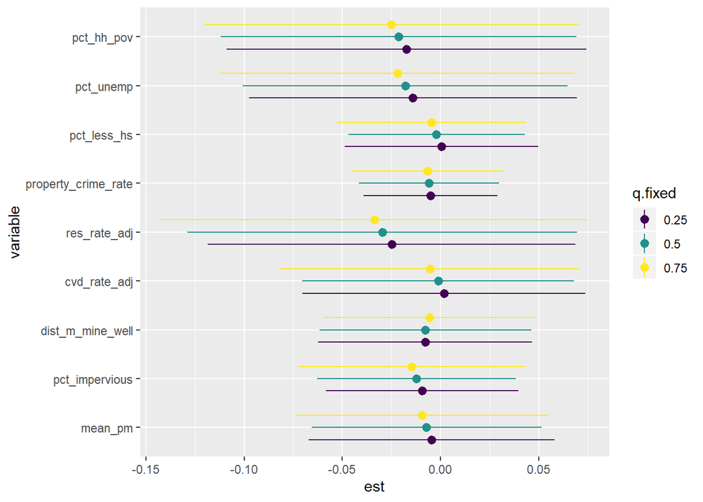

Checking for interation: by how much do the effect sizes for each expsoure change when we increase all the other exposures from the 25th to the 75th percentiles

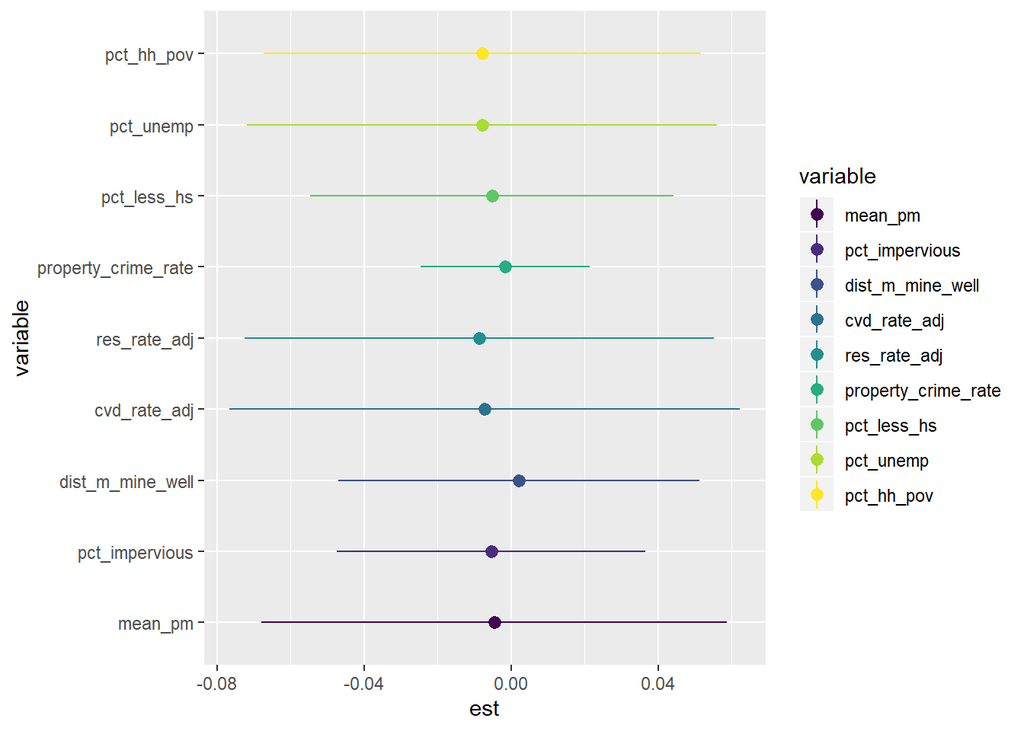